5/20 (Mon) | Experiment

# Correlation Analyses of Automatically Calculated UF Measures

## 1. Introduction

This notebook evaluate the reliability of the UF measures calculated based on the proposed annotation system. More specifically, I conduct correlation analyses between manually and automatically calculated measures. In addition, I conduct the same analyses for different perceived fluency score groups separatelly.

The target measures are follows:

- Speed fluency
  - Articulation rate (AR)
- Breakdown fluency
  - Mid-clause pause ratio (MCPR)
  - End-clause pause ratio (ECPR)
  - Mid-clause pause duration (MCPD)
  - End-clause pause duration (ECPD)
  - Pause ratio (PR)
  - Pause duration (PD)
- Repair fluency
  - Disfluency ratio (DR)
- Composite
  - Speech rate (SR)
  - Mean length of run (MLR)

Note that, in dialogue task, I use mean values of turn-level measures.

Before starting the evaluation, the following code block loads required packages and define global variables.

```python
from typing import List, Tuple, Optional
from pathlib import Path

import numpy as np
import pandas as pd
import matplotlib.pyplot as plt
from scipy.stats import pearsonr

from utils.mfr import logit_2_rating

DATA_DIR = Path("/home/matsuura/Development/app/feature_extraction_api/experiment/data")

TASK = ["Arg_Oly", "Cartoon", "RtSwithoutRAA", "RtSwithRAA", "WoZ_Interview"]

TARGET_UF_MEASURES = [
    "articulation_rate", "mid_clause_pause_ratio", "end_clause_pause_ratio",
    "mid_clause_p-dur", "end_clause_p-dur", "pause_ratio", "mean_pause_duration",
    "dysfluency_ratio", "speech_rate", "mean_length_of_run"
]
```

## 2. Define Functions

This section defines functions for correlation analyses. The following code block defines a function to load measures.

```python
def filter_by_rating(task: str, df_uf: pd.DataFrame, rating_filter: List[int]) -> pd.DataFrame:
    pf_path = DATA_DIR / f"{task}/12_PF_Rating/pf_rating.csv"
    df_pf = pd.read_csv(pf_path)
    uid_list = df_pf["uid"].to_numpy()

    logit_path = pf_path.parent / "logit_all.csv"
    threshold_path = logit_path.parent / "threshold_all.csv"

    df_logit = pd.read_csv(logit_path, index_col=0)
    rating_list = logit_2_rating(df_logit["theta"], threshold_path)

    mask = np.full(rating_list.shape, False, dtype=bool)
    for rating in rating_filter:
        mask = mask | (rating_list == rating)

    uid_list = uid_list[mask]

    if task != "WoZ_Interview":
        df_uf_filtered = df_uf.loc[uid_list, :]
        return df_uf_filtered

    mask = None
    for uid in uid_list:
        uid_prefix = f"{int(uid):03}_"
        uid_mask = df_uf.index.str.startswith(uid_prefix)

        if mask is None:
            mask = uid_mask
        mask = mask | uid_mask

    return df_uf[mask]

def add_pause_ratio(df_uf: pd.DataFrame) -> pd.DataFrame:
    df_uf.loc[:, "pause_ratio"] = df_uf["mid_clause_pause_ratio"] + df_uf["end_clause_pause_ratio"]

    return df_uf

def calculate_mean_uf_measures(df_uf: pd.DataFrame) -> pd.DataFrame:
    data = []

    for uid in range(1, 86):
        uid = str(uid).zfill(3)

        mask = df_uf.index.str.startswith(uid)
        if mask.sum() == 0:
            continue

        df_uf_masked = df_uf[mask]
        mean_uf_measures = df_uf_masked.mean(axis=0, skipna=True)

        row = {
            "uid": uid
        }
        for measure_name in df_uf.columns:
            row[measure_name] = mean_uf_measures[measure_name]
        data.append(row)

    df_uf_mean = pd.DataFrame.from_dict(data).set_index("uid", drop=True)

    return df_uf_mean

def load_measures(task_list: List[str], rating_filter: Optional[List[int]] =None) -> Tuple[pd.DataFrame, pd.DataFrame]:
    df_uf_manu_list = []
    df_uf_auto_list = []

    for task in task_list:
        uf_manu_path = DATA_DIR / f"{task}/09_UF_Measures/uf_measures_manu_pruned.csv"
        uf_auto_path = uf_manu_path.parent / "uf_measures_auto_pruned.csv"

        df_uf_manu = pd.read_csv(uf_manu_path, index_col="uid")
        df_uf_auto = pd.read_csv(uf_auto_path, index_col="uid")

        if rating_filter is not None:
            df_uf_manu = filter_by_rating(task, df_uf_manu, rating_filter)
            df_uf_auto = filter_by_rating(task, df_uf_auto, rating_filter)

        if task == "WoZ_Interview":
            df_uf_manu = calculate_mean_uf_measures(df_uf_manu)
            df_uf_auto = calculate_mean_uf_measures(df_uf_auto)

        df_uf_manu_list.append(df_uf_manu)
        df_uf_auto_list.append(df_uf_auto)

    df_uf_manu = pd.concat(df_uf_manu_list, axis=0)
    df_uf_auto = pd.concat(df_uf_auto_list, axis=0)

    df_uf_manu = add_pause_ratio(df_uf_manu)
    df_uf_auto = add_pause_ratio(df_uf_auto)

    df_uf_manu = df_uf_manu[TARGET_UF_MEASURES].sort_index()
    df_uf_auto = df_uf_auto[TARGET_UF_MEASURES].sort_index()

    return df_uf_manu, df_uf_auto
```

The following code block conducts a correlation analysis.

```python
def correlation_analysis(task: str, df_uf_manu: pd.DataFrame, df_uf_auto: pd.DataFrame, pf_group: str ="All") -> pd.DataFrame:
    fig = plt.figure(figsize=(15, 10))
    ncols = 4
    nrows = (len(TARGET_UF_MEASURES) + ncols - 1) // ncols

    data = []
    columns = ["UF measure", "task", "PF", "r", "p", "sig"]
    for i, measure in enumerate(TARGET_UF_MEASURES):
        ax = fig.add_subplot(nrows, ncols, i + 1)

        measure_manu = df_uf_manu[measure]
        measure_auto = df_uf_auto[measure]

        r, p = pearsonr(measure_manu, measure_auto)
        if p < 0.001:
            sig = "***"
        elif p < 0.01:
            sig = "**"
        elif p < 0.05:
            sig = "*"
        elif p < 0.1:
            sig = "."
        else:
            sig = ""

        data.append([measure, task, pf_group, r, p, sig])

        ax.scatter(measure_manu, measure_auto)
        ax.set_title(f"[{measure}] r={r:.03f}{sig}")
        ax.set_xlabel(f"Manually Calculated Measure")
        ax.set_ylabel(f"Automatically Calculate Measure")

    df_pearsonr = pd.DataFrame(data, columns=columns).set_index("UF measure", drop=True)

    fig.suptitle(f"[{task}] Scatter Plots of Manually and Automatically UF Measures (N={len(df_uf_manu)})", fontweight="bold")
    fig.tight_layout()
    plt.show()

    return df_pearsonr
```

## 3. Correlation Analyses

This section conducts the correlation analyses.

```python
df_cor_list = []
```

### 3.1. All Speakers

Firstly, UF measures obtained from all tasks are analyzed.

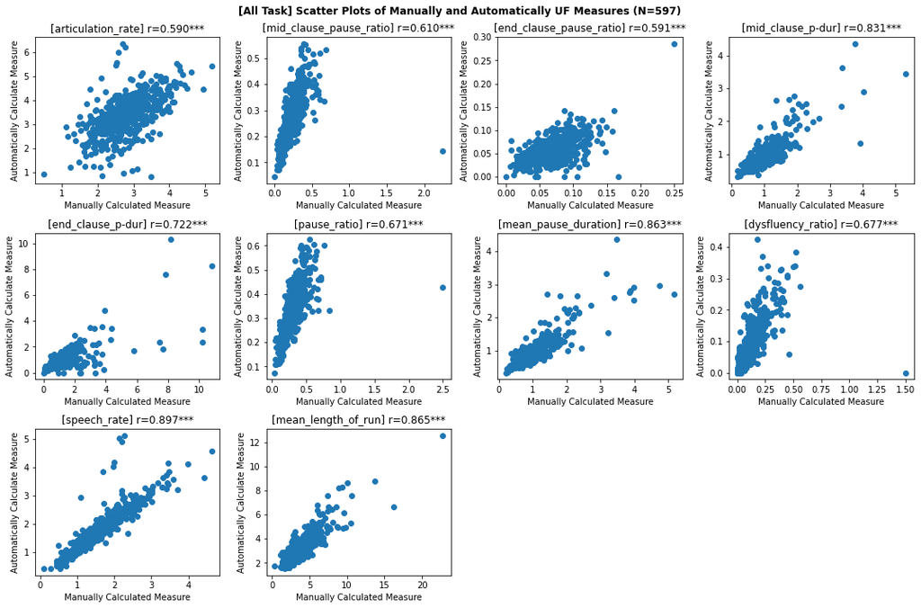

| UF measure | task | PF | r | p | sig |
| --- | --- | --- | --- | --- | --- |
| articulation_rate | All Task | All | 0.589634 | 3.523876e-57 | *** |
| mid_clause_pause_ratio | All Task | All | 0.610434 | 3.098169e-62 | *** |
| end_clause_pause_ratio | All Task | All | 0.591114 | 1.582718e-57 | *** |
| mid_clause_p-dur | All Task | All | 0.831293 | 6.865514e-154 | *** |
| end_clause_p-dur | All Task | All | 0.722316 | 2.264776e-97 | *** |
| pause_ratio | All Task | All | 0.671170 | 2.159764e-79 | *** |
| mean_pause_duration | All Task | All | 0.862956 | 1.511823e-178 | *** |
| dysfluency_ratio | All Task | All | 0.677067 | 2.803532e-81 | *** |
| speech_rate | All Task | All | 0.897389 | 1.388261e-213 | *** |
| mean_length_of_run | All Task | All | 0.865196 | 1.599074e-180 | *** |

```python
df_uf_manu, df_uf_auto = load_measures(TASK)
df_pearsonr = correlation_analysis("All Task", df_uf_manu, df_uf_auto)
df_cor_list.append(df_pearsonr)
df_pearsonr
```

The following five code blocks conduct the analyses for each task.

**Arg_Oly**

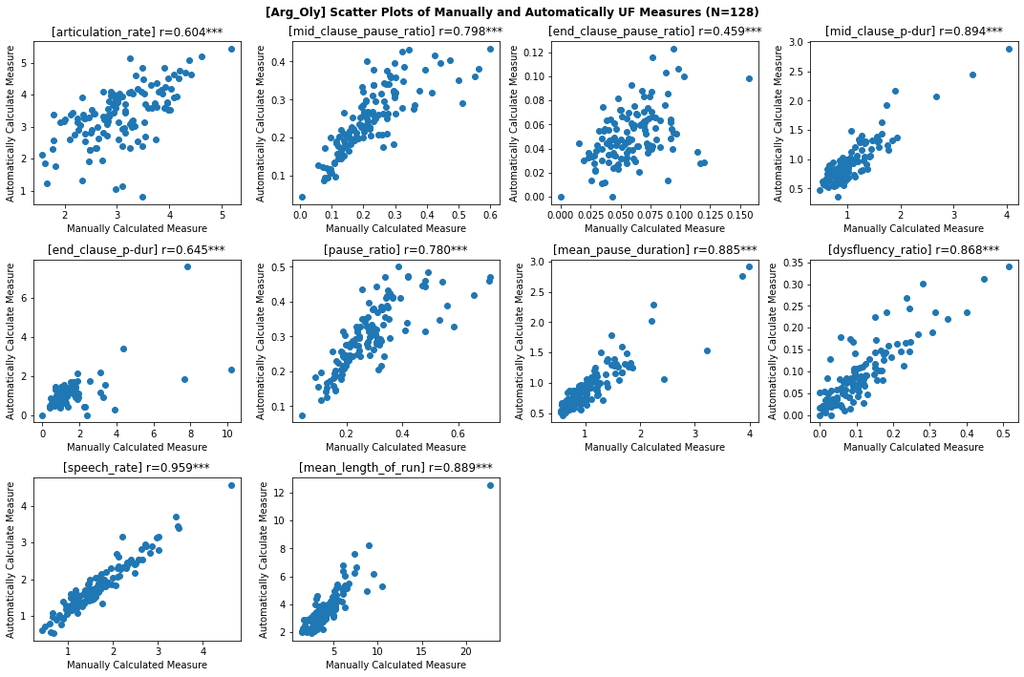

| UF measure | task | PF | r | p | sig |
| --- | --- | --- | --- | --- | --- |
| articulation_rate | Arg_Oly | All | 0.603590 | 4.660326e-14 | *** |
| mid_clause_pause_ratio | Arg_Oly | All | 0.798123 | 1.663451e-29 | *** |
| end_clause_pause_ratio | Arg_Oly | All | 0.458654 | 5.192646e-08 | *** |
| mid_clause_p-dur | Arg_Oly | All | 0.894129 | 8.637202e-46 | *** |
| end_clause_p-dur | Arg_Oly | All | 0.645094 | 2.059634e-16 | *** |
| pause_ratio | Arg_Oly | All | 0.779560 | 2.258493e-27 | *** |
| mean_pause_duration | Arg_Oly | All | 0.885212 | 1.056815e-43 | *** |
| dysfluency_ratio | Arg_Oly | All | 0.868332 | 3.467728e-40 | *** |
| speech_rate | Arg_Oly | All | 0.958631 | 1.296455e-70 | *** |
| mean_length_of_run | Arg_Oly | All | 0.888903 | 1.519183e-44 | *** |

```python
task = "Arg_Oly"
df_uf_manu, df_uf_auto = load_measures([task])
df_pearsonr = correlation_analysis(task, df_uf_manu, df_uf_auto)
df_cor_list.append(df_pearsonr)
df_pearsonr
```

**Cartoon**

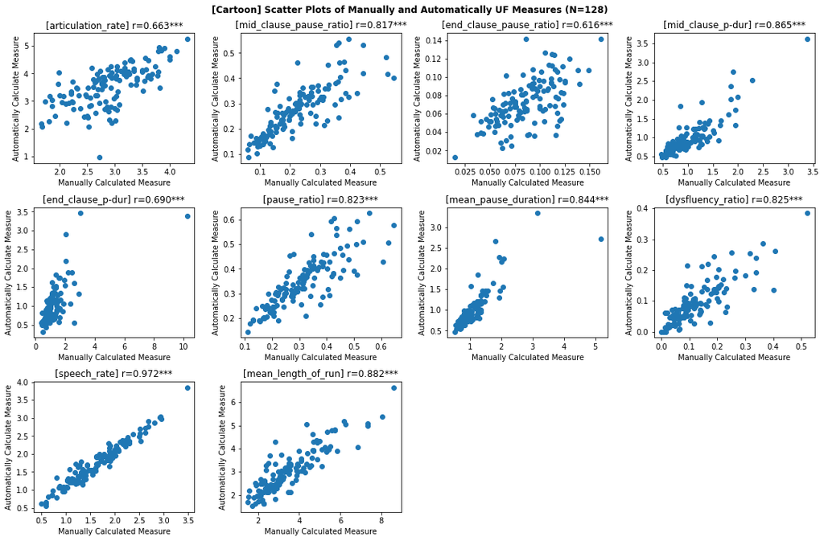

| UF measure | task | PF | r | p | sig |
| --- | --- | --- | --- | --- | --- |
| articulation_rate | Cartoon | All | 0.662920 | 1.539219e-17 | *** |
| mid_clause_pause_ratio | Cartoon | All | 0.817323 | 5.849219e-32 | *** |
| end_clause_pause_ratio | Cartoon | All | 0.616133 | 9.846097e-15 | *** |
| mid_clause_p-dur | Cartoon | All | 0.865010 | 1.495012e-39 | *** |
| end_clause_p-dur | Cartoon | All | 0.689903 | 2.128440e-19 | *** |
| pause_ratio | Cartoon | All | 0.823424 | 8.438912e-33 | *** |
| mean_pause_duration | Cartoon | All | 0.844125 | 6.498815e-36 | *** |
| dysfluency_ratio | Cartoon | All | 0.825443 | 4.373439e-33 | *** |
| speech_rate | Cartoon | All | 0.971919 | 4.907339e-81 | *** |
| mean_length_of_run | Cartoon | All | 0.881631 | 6.521960e-43 | *** |

```python
task = "Cartoon"
df_uf_manu, df_uf_auto = load_measures([task])
df_pearsonr = correlation_analysis(task, df_uf_manu, df_uf_auto)
df_cor_list.append(df_pearsonr)
df_pearsonr
```

**RtSwithoutRAA**

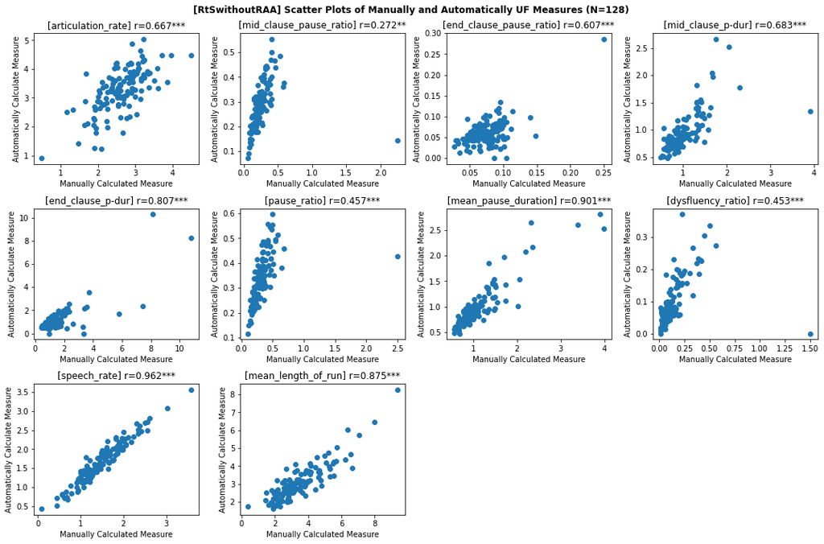

| UF measure | task | PF | r | p | sig |
| --- | --- | --- | --- | --- | --- |
| articulation_rate | RtSwithoutRAA | All | 0.667370 | 7.834117e-18 | *** |
| mid_clause_pause_ratio | RtSwithoutRAA | All | 0.272356 | 1.869990e-03 | ** |
| end_clause_pause_ratio | RtSwithoutRAA | All | 0.606527 | 3.258329e-14 | *** |
| mid_clause_p-dur | RtSwithoutRAA | All | 0.682748 | 6.926443e-19 | *** |
| end_clause_p-dur | RtSwithoutRAA | All | 0.806936 | 1.345252e-30 | *** |
| pause_ratio | RtSwithoutRAA | All | 0.456787 | 5.973305e-08 | *** |
| mean_pause_duration | RtSwithoutRAA | All | 0.900817 | 1.755147e-47 | *** |
| dysfluency_ratio | RtSwithoutRAA | All | 0.452824 | 8.018253e-08 | *** |
| speech_rate | RtSwithoutRAA | All | 0.961821 | 9.125141e-73 | *** |
| mean_length_of_run | RtSwithoutRAA | All | 0.875152 | 1.517123e-41 | *** |

```python
task = "RtSwithoutRAA"
df_uf_manu, df_uf_auto = load_measures([task])
df_pearsonr = correlation_analysis(task, df_uf_manu, df_uf_auto)
df_cor_list.append(df_pearsonr)
df_pearsonr
```

**RtSwithRAA**

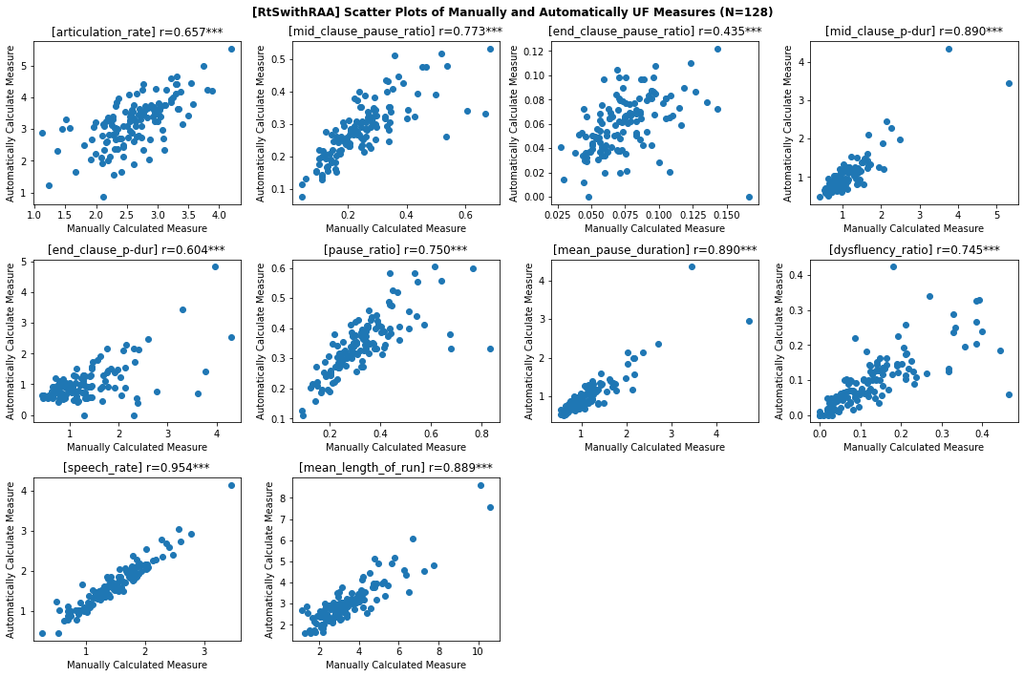

| UF measure | task | PF | r | p | sig |
| --- | --- | --- | --- | --- | --- |
| articulation_rate | RtSwithRAA | All | 0.656952 | 3.740176e-17 | *** |
| mid_clause_pause_ratio | RtSwithRAA | All | 0.773241 | 1.079482e-26 | *** |
| end_clause_pause_ratio | RtSwithRAA | All | 0.434886 | 2.904445e-07 | *** |
| mid_clause_p-dur | RtSwithRAA | All | 0.890385 | 6.839372e-45 | *** |
| end_clause_p-dur | RtSwithRAA | All | 0.604366 | 4.241141e-14 | *** |
| pause_ratio | RtSwithRAA | All | 0.749655 | 2.439831e-24 | *** |
| mean_pause_duration | RtSwithRAA | All | 0.890003 | 8.407834e-45 | *** |
| dysfluency_ratio | RtSwithRAA | All | 0.744658 | 7.123348e-24 | *** |
| speech_rate | RtSwithRAA | All | 0.953946 | 9.643402e-68 | *** |
| mean_length_of_run | RtSwithRAA | All | 0.889096 | 1.370346e-44 | *** |

```python
task = "RtSwithRAA"
df_uf_manu, df_uf_auto = load_measures([task])
df_pearsonr = correlation_analysis(task, df_uf_manu, df_uf_auto)
df_cor_list.append(df_pearsonr)
df_pearsonr
```

**WoZ_Interview**

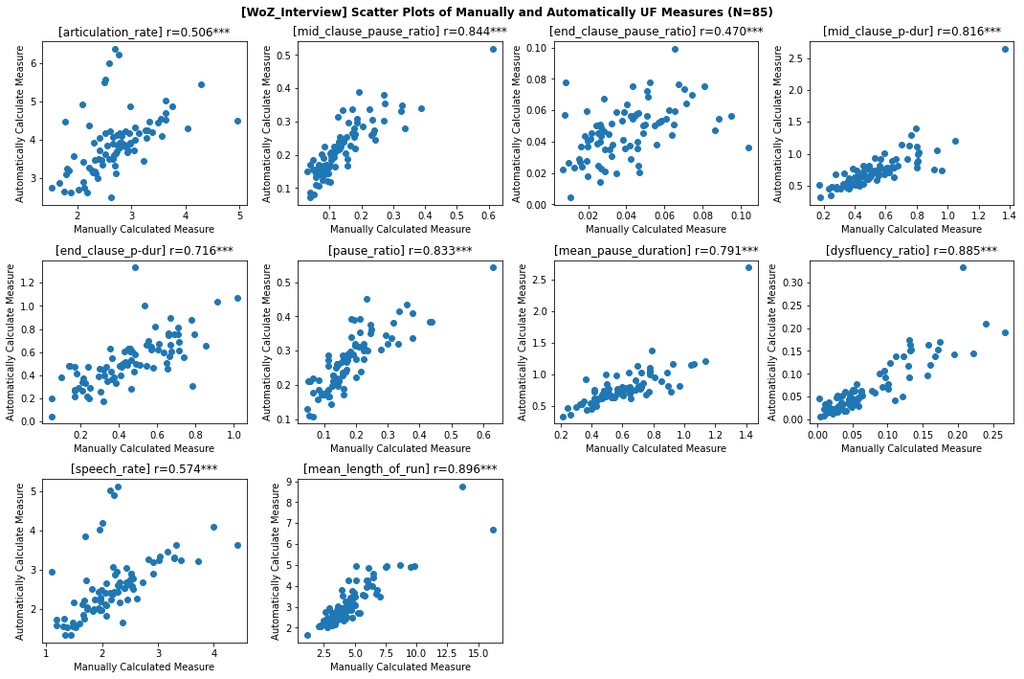

| UF measure | task | PF | r | p | sig |
| --- | --- | --- | --- | --- | --- |
| articulation_rate | WoZ_Interview | All | 0.505805 | 7.897640e-07 | *** |
| mid_clause_pause_ratio | WoZ_Interview | All | 0.843644 | 3.928584e-24 | *** |
| end_clause_pause_ratio | WoZ_Interview | All | 0.470214 | 5.607791e-06 | *** |
| mid_clause_p-dur | WoZ_Interview | All | 0.815942 | 1.884664e-21 | *** |
| end_clause_p-dur | WoZ_Interview | All | 0.715630 | 1.400914e-14 | *** |
| pause_ratio | WoZ_Interview | All | 0.832940 | 4.876290e-23 | *** |
| mean_pause_duration | WoZ_Interview | All | 0.791283 | 2.031118e-19 | *** |
| dysfluency_ratio | WoZ_Interview | All | 0.884638 | 3.093951e-29 | *** |
| speech_rate | WoZ_Interview | All | 0.574353 | 9.064875e-09 | *** |
| mean_length_of_run | WoZ_Interview | All | 0.895825 | 5.667238e-31 | *** |

```python
task = "WoZ_Interview"
df_uf_manu, df_uf_auto = load_measures([task])
df_pearsonr = correlation_analysis(task, df_uf_manu, df_uf_auto)
df_cor_list.append(df_pearsonr)
df_pearsonr
```

### 3.2. Beginners

The following code blocks conduct the analyses of *beginners'* speech.

**Arg_Oly**

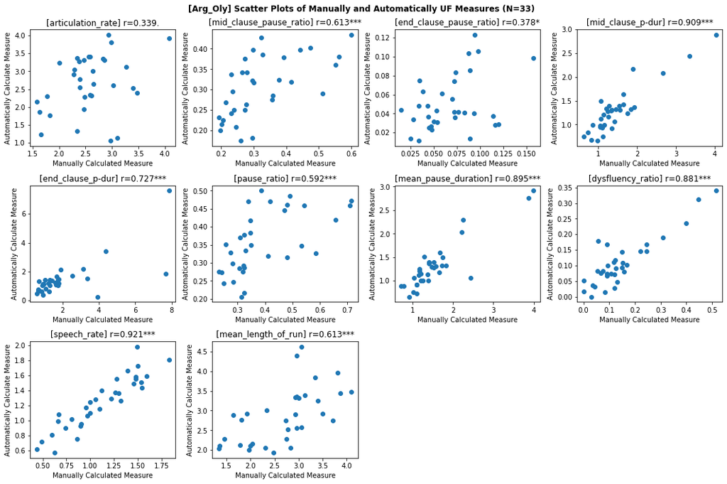

| UF measure | task | PF | r | p | sig |
| --- | --- | --- | --- | --- | --- |
| articulation_rate | Arg_Oly | Low | 0.339295 | 5.339867e-02 | . |
| mid_clause_pause_ratio | Arg_Oly | Low | 0.612533 | 1.513094e-04 | *** |
| end_clause_pause_ratio | Arg_Oly | Low | 0.377696 | 3.023280e-02 | * |
| mid_clause_p-dur | Arg_Oly | Low | 0.909305 | 2.440124e-13 | *** |
| end_clause_p-dur | Arg_Oly | Low | 0.726807 | 1.670360e-06 | *** |
| pause_ratio | Arg_Oly | Low | 0.592293 | 2.819752e-04 | *** |
| mean_pause_duration | Arg_Oly | Low | 0.894709 | 2.222456e-12 | *** |
| dysfluency_ratio | Arg_Oly | Low | 0.880504 | 1.427386e-11 | *** |
| speech_rate | Arg_Oly | Low | 0.920803 | 3.237614e-14 | *** |
| mean_length_of_run | Arg_Oly | Low | 0.612538 | 1.512853e-04 | *** |

```python
task = "Arg_Oly"
rating_filter = [0, 1, 2]
df_uf_manu, df_uf_auto = load_measures([task], rating_filter)
df_pearsonr = correlation_analysis(task, df_uf_manu, df_uf_auto, pf_group="Low")
df_cor_list.append(df_pearsonr)
df_pearsonr
```

**Cartoon**

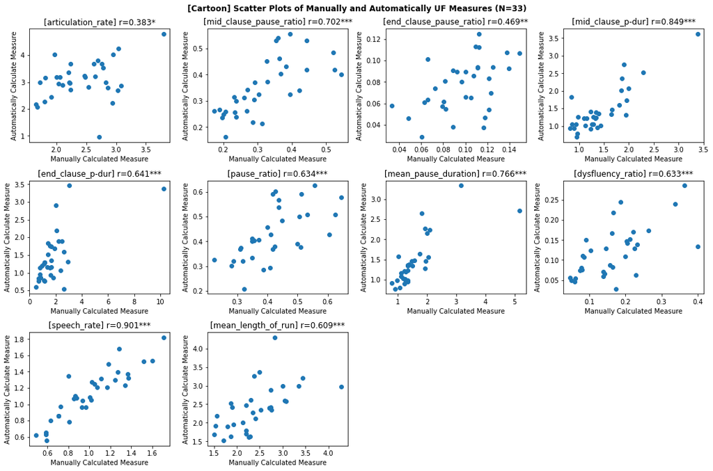

| UF measure | task | PF | r | p | sig |
| --- | --- | --- | --- | --- | --- |
| articulation_rate | Cartoon | Low | 0.382760 | 2.791397e-02 | * |
| mid_clause_pause_ratio | Cartoon | Low | 0.701511 | 5.411849e-06 | *** |
| end_clause_pause_ratio | Cartoon | Low | 0.468819 | 5.923247e-03 | ** |
| mid_clause_p-dur | Cartoon | Low | 0.849031 | 4.258430e-10 | *** |
| end_clause_p-dur | Cartoon | Low | 0.641048 | 5.835331e-05 | *** |
| pause_ratio | Cartoon | Low | 0.634057 | 7.436086e-05 | *** |
| mean_pause_duration | Cartoon | Low | 0.766339 | 2.005637e-07 | *** |
| dysfluency_ratio | Cartoon | Low | 0.632775 | 7.769066e-05 | *** |
| speech_rate | Cartoon | Low | 0.900640 | 9.438431e-13 | *** |
| mean_length_of_run | Cartoon | Low | 0.609146 | 1.684200e-04 | *** |

```python
task = "Cartoon"
rating_filter = [0, 1, 2]
df_uf_manu, df_uf_auto = load_measures([task], rating_filter)
df_pearsonr = correlation_analysis(task, df_uf_manu, df_uf_auto, pf_group="Low")
df_cor_list.append(df_pearsonr)
df_pearsonr
```

**RtSwithoutRAA**

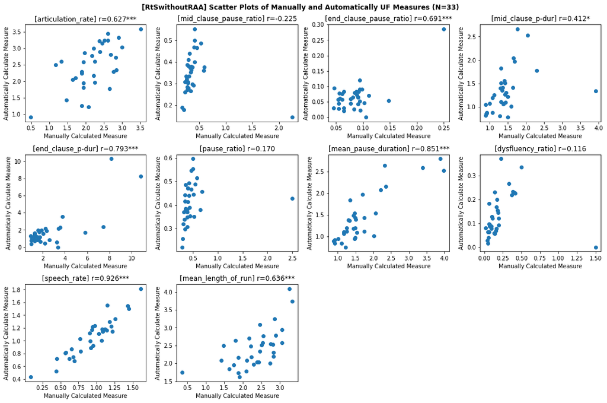

| UF measure | task | PF | r | p | sig |
| --- | --- | --- | --- | --- | --- |
| articulation_rate | RtSwithoutRAA | Low | 0.627499 | 9.284939e-05 | *** |
| mid_clause_pause_ratio | RtSwithoutRAA | Low | -0.225260 | 2.075260e-01 |  |
| end_clause_pause_ratio | RtSwithoutRAA | Low | 0.691113 | 8.479239e-06 | *** |
| mid_clause_p-dur | RtSwithoutRAA | Low | 0.412052 | 1.718465e-02 | * |
| end_clause_p-dur | RtSwithoutRAA | Low | 0.792721 | 3.821360e-08 | *** |
| pause_ratio | RtSwithoutRAA | Low | 0.170115 | 3.439032e-01 |  |
| mean_pause_duration | RtSwithoutRAA | Low | 0.850704 | 3.626969e-10 | *** |
| dysfluency_ratio | RtSwithoutRAA | Low | 0.116282 | 5.192988e-01 |  |
| speech_rate | RtSwithoutRAA | Low | 0.926033 | 1.165119e-14 | *** |
| mean_length_of_run | RtSwithoutRAA | Low | 0.635701 | 7.027806e-05 | *** |

```python
task = "RtSwithoutRAA"
rating_filter = [0, 1, 2]
df_uf_manu, df_uf_auto = load_measures([task], rating_filter)
df_pearsonr = correlation_analysis(task, df_uf_manu, df_uf_auto, pf_group="Low")
df_cor_list.append(df_pearsonr)
df_pearsonr
```

**RtSwithRAA**

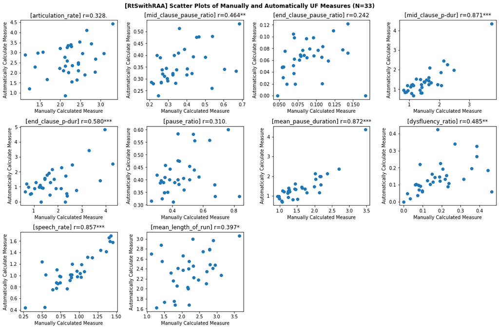

| UF measure | task | PF | r | p | sig |
| --- | --- | --- | --- | --- | --- |
| articulation_rate | RtSwithRAA | Low | 0.327898 | 6.247911e-02 | . |
| mid_clause_pause_ratio | RtSwithRAA | Low | 0.464229 | 6.499212e-03 | ** |
| end_clause_pause_ratio | RtSwithRAA | Low | 0.242207 | 1.744498e-01 |  |
| mid_clause_p-dur | RtSwithRAA | Low | 0.871121 | 4.305217e-11 | *** |
| end_clause_p-dur | RtSwithRAA | Low | 0.580472 | 3.980814e-04 | *** |
| pause_ratio | RtSwithRAA | Low | 0.310149 | 7.898988e-02 | . |
| mean_pause_duration | RtSwithRAA | Low | 0.871575 | 4.089547e-11 | *** |
| dysfluency_ratio | RtSwithRAA | Low | 0.485353 | 4.195814e-03 | ** |
| speech_rate | RtSwithRAA | Low | 0.856674 | 2.012388e-10 | *** |
| mean_length_of_run | RtSwithRAA | Low | 0.396698 | 2.227310e-02 | * |

```python
task = "RtSwithRAA"
rating_filter = [0, 1, 2]
df_uf_manu, df_uf_auto = load_measures([task], rating_filter)
df_pearsonr = correlation_analysis(task, df_uf_manu, df_uf_auto, pf_group="Low")
df_cor_list.append(df_pearsonr)
df_pearsonr
```

**WoZ_Interview**

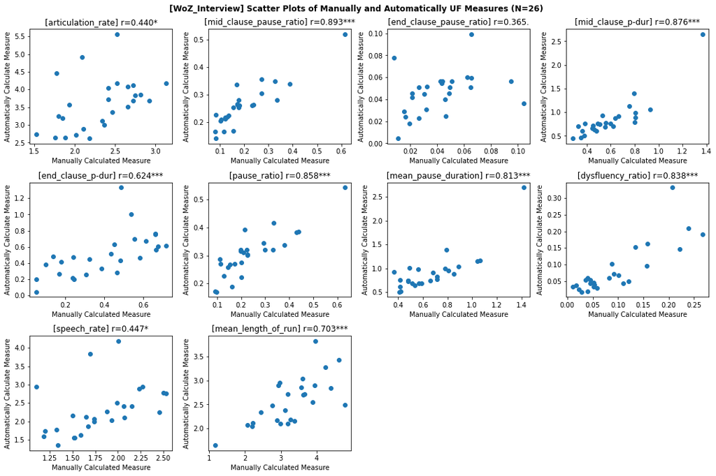

| UF measure | task | PF | r | p | sig |
| --- | --- | --- | --- | --- | --- |
| articulation_rate | WoZ_Interview | Low | 0.440002 | 2.448785e-02 | * |
| mid_clause_pause_ratio | WoZ_Interview | Low | 0.893429 | 8.142885e-10 | *** |
| end_clause_pause_ratio | WoZ_Interview | Low | 0.364973 | 6.675686e-02 | . |
| mid_clause_p-dur | WoZ_Interview | Low | 0.876477 | 4.372576e-09 | *** |
| end_clause_p-dur | WoZ_Interview | Low | 0.623999 | 6.578838e-04 | *** |
| pause_ratio | WoZ_Interview | Low | 0.858341 | 2.052555e-08 | *** |
| mean_pause_duration | WoZ_Interview | Low | 0.812985 | 4.490080e-07 | *** |
| dysfluency_ratio | WoZ_Interview | Low | 0.838497 | 8.886115e-08 | *** |
| speech_rate | WoZ_Interview | Low | 0.446865 | 2.209919e-02 | * |
| mean_length_of_run | WoZ_Interview | Low | 0.703111 | 6.174044e-05 | *** |

```python
task = "WoZ_Interview"
rating_filter = [0, 1]
df_uf_manu, df_uf_auto = load_measures([task], rating_filter)
df_pearsonr = correlation_analysis(task, df_uf_manu, df_uf_auto, pf_group="Low")
df_cor_list.append(df_pearsonr)
df_pearsonr
```

### 3.3. Intermediate Speakers

The following code blocks conduct the analyses of *intemediate speakers'* speech.

**Arg_Oly**

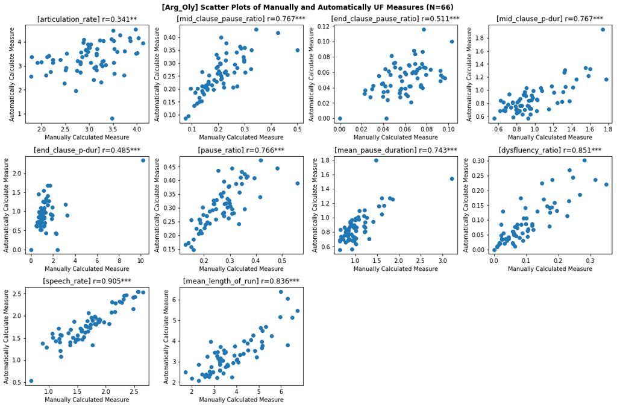

| UF measure | task | PF | r | p | sig |
| --- | --- | --- | --- | --- | --- |
| articulation_rate | Arg_Oly | Mid | 0.341121 | 5.064049e-03 | ** |
| mid_clause_pause_ratio | Arg_Oly | Mid | 0.767315 | 5.732240e-14 | *** |
| end_clause_pause_ratio | Arg_Oly | Mid | 0.511493 | 1.138227e-05 | *** |
| mid_clause_p-dur | Arg_Oly | Mid | 0.766699 | 6.174061e-14 | *** |
| end_clause_p-dur | Arg_Oly | Mid | 0.485172 | 3.647792e-05 | *** |
| pause_ratio | Arg_Oly | Mid | 0.766394 | 6.404135e-14 | *** |
| mean_pause_duration | Arg_Oly | Mid | 0.743383 | 8.759321e-13 | *** |
| dysfluency_ratio | Arg_Oly | Mid | 0.851120 | 1.423627e-19 | *** |
| speech_rate | Arg_Oly | Mid | 0.904796 | 2.047654e-25 | *** |
| mean_length_of_run | Arg_Oly | Mid | 0.835952 | 2.482015e-18 | *** |

```python
task = "Arg_Oly"
rating_filter = [3, 4, 5]
df_uf_manu, df_uf_auto = load_measures([task], rating_filter)
df_pearsonr = correlation_analysis(task, df_uf_manu, df_uf_auto, pf_group="Mid")
df_cor_list.append(df_pearsonr)
df_pearsonr
```

**Cartoon**

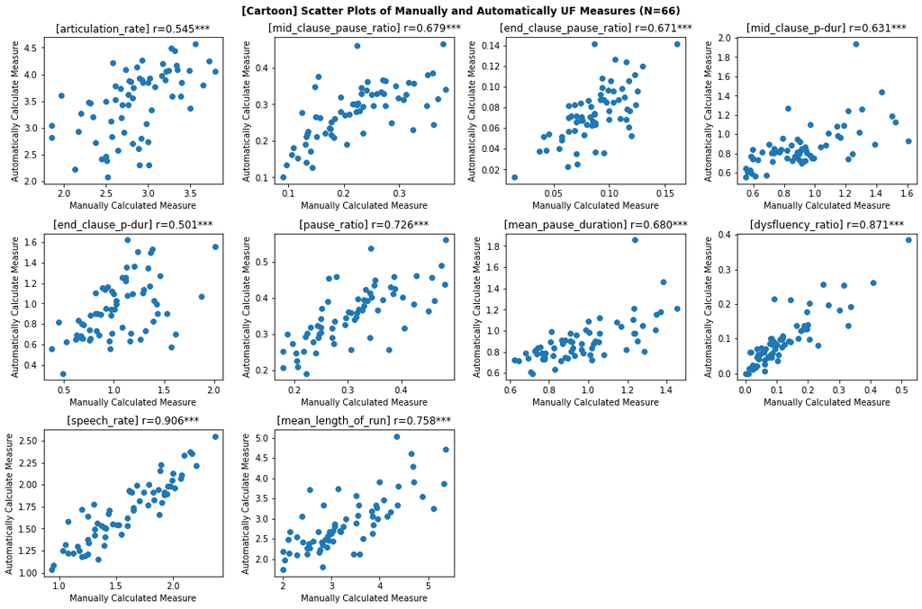

| UF measure | task | PF | r | p | sig |
| --- | --- | --- | --- | --- | --- |
| articulation_rate | Cartoon | Mid | 0.545260 | 2.201050e-06 | *** |
| mid_clause_pause_ratio | Cartoon | Mid | 0.678764 | 3.767810e-10 | *** |
| end_clause_pause_ratio | Cartoon | Mid | 0.671116 | 6.985983e-10 | *** |
| mid_clause_p-dur | Cartoon | Mid | 0.631200 | 1.333758e-08 | *** |
| end_clause_p-dur | Cartoon | Mid | 0.501148 | 1.819720e-05 | *** |
| pause_ratio | Cartoon | Mid | 0.725846 | 5.376043e-12 | *** |
| mean_pause_duration | Cartoon | Mid | 0.679601 | 3.517529e-10 | *** |
| dysfluency_ratio | Cartoon | Mid | 0.871378 | 1.828851e-21 | *** |
| speech_rate | Cartoon | Mid | 0.906325 | 1.249282e-25 | *** |
| mean_length_of_run | Cartoon | Mid | 0.757566 | 1.807655e-13 | *** |

```python
task = "Cartoon"
rating_filter = [3, 4, 5]
df_uf_manu, df_uf_auto = load_measures([task], rating_filter)
df_pearsonr = correlation_analysis(task, df_uf_manu, df_uf_auto, pf_group="Mid")
df_cor_list.append(df_pearsonr)
df_pearsonr
```

**RtSwithoutRAA**

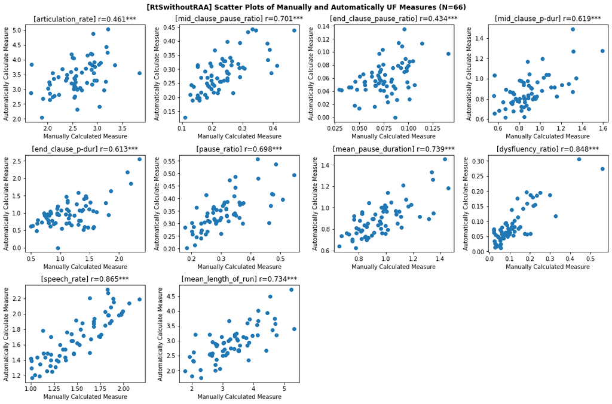

| UF measure | task | PF | r | p | sig |
| --- | --- | --- | --- | --- | --- |
| articulation_rate | RtSwithoutRAA | Mid | 0.460619 | 9.951770e-05 | *** |
| mid_clause_pause_ratio | RtSwithoutRAA | Mid | 0.700767 | 5.727243e-11 | *** |
| end_clause_pause_ratio | RtSwithoutRAA | Mid | 0.434381 | 2.682302e-04 | *** |
| mid_clause_p-dur | RtSwithoutRAA | Mid | 0.619215 | 2.983913e-08 | *** |
| end_clause_p-dur | RtSwithoutRAA | Mid | 0.612657 | 4.570801e-08 | *** |
| pause_ratio | RtSwithoutRAA | Mid | 0.698062 | 7.285362e-11 | *** |
| mean_pause_duration | RtSwithoutRAA | Mid | 0.738581 | 1.460408e-12 | *** |
| dysfluency_ratio | RtSwithoutRAA | Mid | 0.848347 | 2.456858e-19 | *** |
| speech_rate | RtSwithoutRAA | Mid | 0.864756 | 8.199122e-21 | *** |
| mean_length_of_run | RtSwithoutRAA | Mid | 0.733789 | 2.405507e-12 | *** |

```python
task = "RtSwithoutRAA"
rating_filter = [3, 4, 5]
df_uf_manu, df_uf_auto = load_measures([task], rating_filter)
df_pearsonr = correlation_analysis(task, df_uf_manu, df_uf_auto, pf_group="Mid")
df_cor_list.append(df_pearsonr)
df_pearsonr
```

**RtSwithRAA**

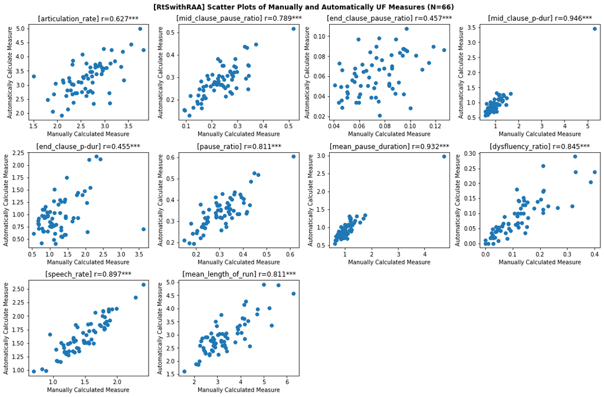

| UF measure | task | PF | r | p | sig |
| --- | --- | --- | --- | --- | --- |
| articulation_rate | RtSwithRAA | Mid | 0.627101 | 1.763486e-08 | *** |
| mid_clause_pause_ratio | RtSwithRAA | Mid | 0.788644 | 3.780729e-15 | *** |
| end_clause_pause_ratio | RtSwithRAA | Mid | 0.456702 | 1.159886e-04 | *** |
| mid_clause_p-dur | RtSwithRAA | Mid | 0.945670 | 6.195045e-33 | *** |
| end_clause_p-dur | RtSwithRAA | Mid | 0.455157 | 1.231488e-04 | *** |
| pause_ratio | RtSwithRAA | Mid | 0.810563 | 1.636390e-16 | *** |
| mean_pause_duration | RtSwithRAA | Mid | 0.931960 | 6.715535e-30 | *** |
| dysfluency_ratio | RtSwithRAA | Mid | 0.844933 | 4.739575e-19 | *** |
| speech_rate | RtSwithRAA | Mid | 0.896842 | 2.354487e-24 | *** |
| mean_length_of_run | RtSwithRAA | Mid | 0.811291 | 1.464330e-16 | *** |

```python
task = "RtSwithRAA"
rating_filter = [3, 4, 5]
df_uf_manu, df_uf_auto = load_measures([task], rating_filter)
df_pearsonr = correlation_analysis(task, df_uf_manu, df_uf_auto, pf_group="Mid")
df_cor_list.append(df_pearsonr)
df_pearsonr
```

**WoZ_Interview**

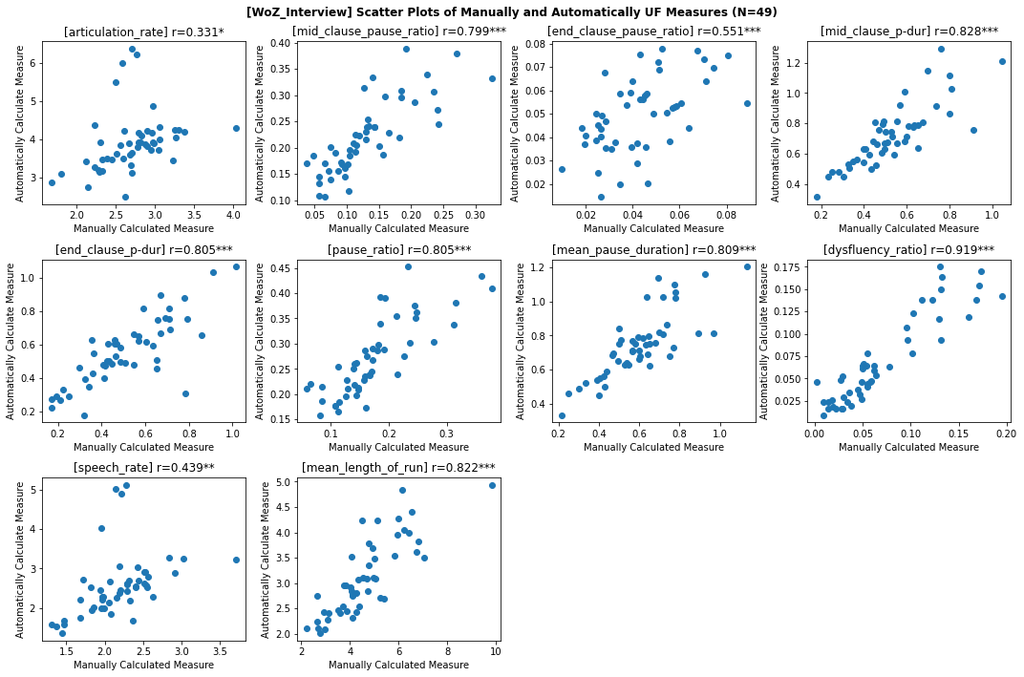

| UF measure | task | PF | r | p | sig |
| --- | --- | --- | --- | --- | --- |
| articulation_rate | WoZ_Interview | Mid | 0.331381 | 2.002237e-02 | * |
| mid_clause_pause_ratio | WoZ_Interview | Mid | 0.799340 | 5.740964e-12 | *** |
| end_clause_pause_ratio | WoZ_Interview | Mid | 0.551077 | 4.072474e-05 | *** |
| mid_clause_p-dur | WoZ_Interview | Mid | 0.828073 | 2.132923e-13 | *** |
| end_clause_p-dur | WoZ_Interview | Mid | 0.805000 | 3.134038e-12 | *** |
| pause_ratio | WoZ_Interview | Mid | 0.805256 | 3.048041e-12 | *** |
| mean_pause_duration | WoZ_Interview | Mid | 0.808684 | 2.091358e-12 | *** |
| dysfluency_ratio | WoZ_Interview | Mid | 0.918623 | 1.399175e-20 | *** |
| speech_rate | WoZ_Interview | Mid | 0.438690 | 1.615684e-03 | ** |
| mean_length_of_run | WoZ_Interview | Mid | 0.821686 | 4.663107e-13 | *** |

```python
task = "WoZ_Interview"
rating_filter = [2, 3]
df_uf_manu, df_uf_auto = load_measures([task], rating_filter)
df_pearsonr = correlation_analysis(task, df_uf_manu, df_uf_auto, pf_group="Mid")
df_cor_list.append(df_pearsonr)
df_pearsonr
```

### 3.4. Advanced Speakers

The following code blocks conduct the analyses of *advanced speakers'* speech.

**Arg_Oly**

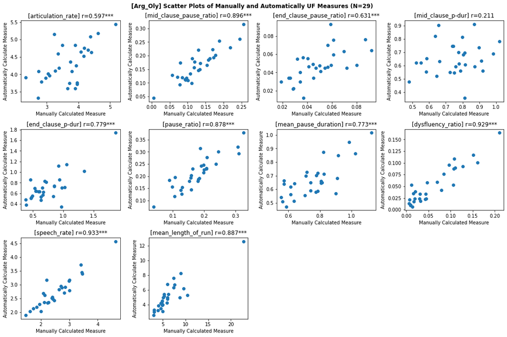

| UF measure | task | PF | r | p | sig |
| --- | --- | --- | --- | --- | --- |
| articulation_rate | Arg_Oly | High | 0.597381 | 6.225787e-04 | *** |
| mid_clause_pause_ratio | Arg_Oly | High | 0.896022 | 5.080391e-11 | *** |
| end_clause_pause_ratio | Arg_Oly | High | 0.630799 | 2.440069e-04 | *** |
| mid_clause_p-dur | Arg_Oly | High | 0.210571 | 2.728900e-01 |  |
| end_clause_p-dur | Arg_Oly | High | 0.779375 | 6.298314e-07 | *** |
| pause_ratio | Arg_Oly | High | 0.878217 | 3.848455e-10 | *** |
| mean_pause_duration | Arg_Oly | High | 0.772504 | 9.115586e-07 | *** |
| dysfluency_ratio | Arg_Oly | High | 0.929424 | 3.325226e-13 | *** |
| speech_rate | Arg_Oly | High | 0.933196 | 1.620298e-13 | *** |
| mean_length_of_run | Arg_Oly | High | 0.886692 | 1.530912e-10 | *** |

```python
task = "Arg_Oly"
rating_filter = [6, 7, 8]
df_uf_manu, df_uf_auto = load_measures([task], rating_filter)
df_pearsonr = correlation_analysis(task, df_uf_manu, df_uf_auto, pf_group="High")
df_cor_list.append(df_pearsonr)
df_pearsonr
```

**Cartoon**

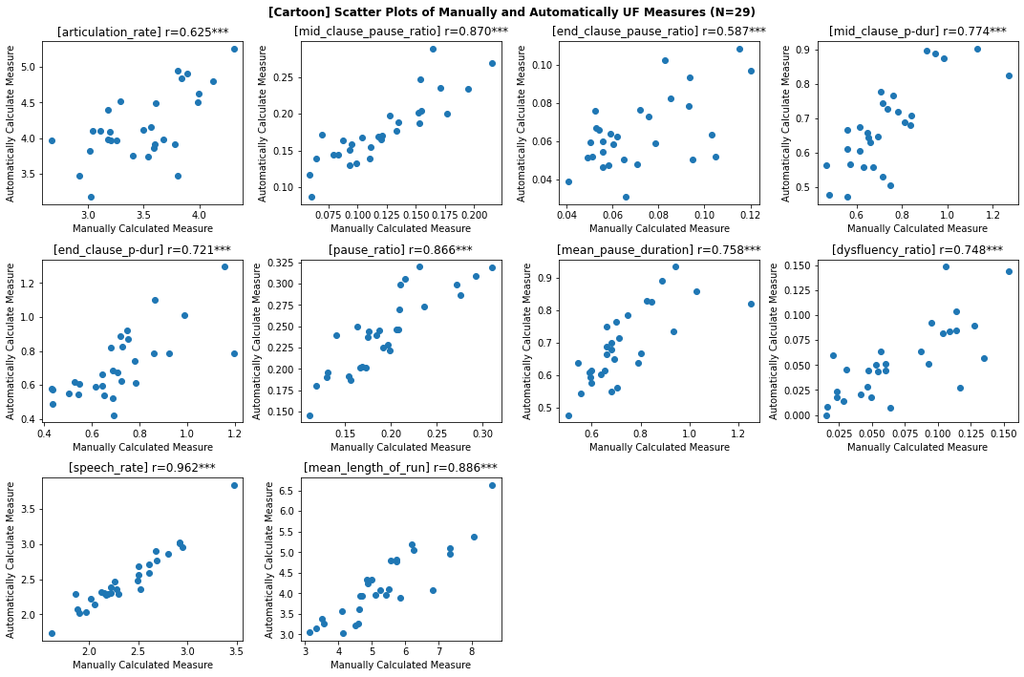

| UF measure | task | PF | r | p | sig |
| --- | --- | --- | --- | --- | --- |
| articulation_rate | Cartoon | High | 0.625354 | 2.863183e-04 | *** |
| mid_clause_pause_ratio | Cartoon | High | 0.869722 | 9.076416e-10 | *** |
| end_clause_pause_ratio | Cartoon | High | 0.587261 | 8.104824e-04 | *** |
| mid_clause_p-dur | Cartoon | High | 0.774088 | 8.380298e-07 | *** |
| end_clause_p-dur | Cartoon | High | 0.720867 | 1.029137e-05 | *** |
| pause_ratio | Cartoon | High | 0.866269 | 1.264811e-09 | *** |
| mean_pause_duration | Cartoon | High | 0.757884 | 1.922319e-06 | *** |
| dysfluency_ratio | Cartoon | High | 0.748348 | 3.043104e-06 | *** |
| speech_rate | Cartoon | High | 0.962018 | 9.410157e-17 | *** |
| mean_length_of_run | Cartoon | High | 0.886322 | 1.596180e-10 | *** |

```python
task = "Cartoon"
rating_filter = [6, 7, 8]
df_uf_manu, df_uf_auto = load_measures([task], rating_filter)
df_pearsonr = correlation_analysis(task, df_uf_manu, df_uf_auto, pf_group="High")
df_cor_list.append(df_pearsonr)
df_pearsonr
```

**RtSwithoutRAA**

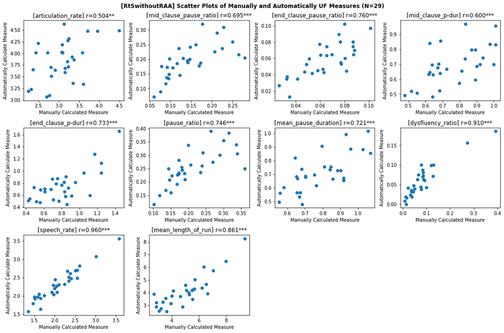

| UF measure | task | PF | r | p | sig |
| --- | --- | --- | --- | --- | --- |
| articulation_rate | RtSwithoutRAA | High | 0.504377 | 5.270102e-03 | ** |
| mid_clause_pause_ratio | RtSwithoutRAA | High | 0.695295 | 2.834200e-05 | *** |
| end_clause_pause_ratio | RtSwithoutRAA | High | 0.759839 | 1.745017e-06 | *** |
| mid_clause_p-dur | RtSwithoutRAA | High | 0.599811 | 5.835998e-04 | *** |
| end_clause_p-dur | RtSwithoutRAA | High | 0.732536 | 6.245339e-06 | *** |
| pause_ratio | RtSwithoutRAA | High | 0.746467 | 3.323852e-06 | *** |
| mean_pause_duration | RtSwithoutRAA | High | 0.720814 | 1.031429e-05 | *** |
| dysfluency_ratio | RtSwithoutRAA | High | 0.909586 | 8.359080e-12 | *** |
| speech_rate | RtSwithoutRAA | High | 0.959513 | 2.196216e-16 | *** |
| mean_length_of_run | RtSwithoutRAA | High | 0.860517 | 2.155145e-09 | *** |

```python
task = "RtSwithoutRAA"
rating_filter = [6, 7, 8]
df_uf_manu, df_uf_auto = load_measures([task], rating_filter)
df_pearsonr = correlation_analysis(task, df_uf_manu, df_uf_auto, pf_group="High")
df_cor_list.append(df_pearsonr)
df_pearsonr
```

**RtSwithRAA**

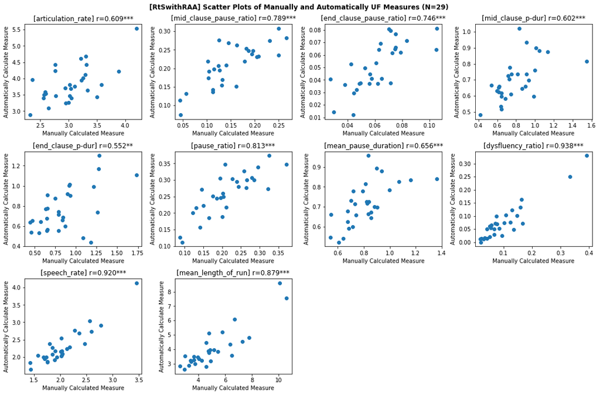

| UF measure | task | PF | r | p | sig |
| --- | --- | --- | --- | --- | --- |
| articulation_rate | RtSwithRAA | High | 0.608741 | 4.581266e-04 | *** |
| mid_clause_pause_ratio | RtSwithRAA | High | 0.788724 | 3.727592e-07 | *** |
| end_clause_pause_ratio | RtSwithRAA | High | 0.745827 | 3.424446e-06 | *** |
| mid_clause_p-dur | RtSwithRAA | High | 0.602108 | 5.487359e-04 | *** |
| end_clause_p-dur | RtSwithRAA | High | 0.552041 | 1.904387e-03 | ** |
| pause_ratio | RtSwithRAA | High | 0.813302 | 8.209926e-08 | *** |
| mean_pause_duration | RtSwithRAA | High | 0.656185 | 1.110506e-04 | *** |
| dysfluency_ratio | RtSwithRAA | High | 0.937659 | 6.544407e-14 | *** |
| speech_rate | RtSwithRAA | High | 0.919710 | 1.788529e-12 | *** |
| mean_length_of_run | RtSwithRAA | High | 0.878899 | 3.582333e-10 | *** |

```python
task = "RtSwithRAA"
rating_filter = [6, 7, 8]
df_uf_manu, df_uf_auto = load_measures([task], rating_filter)
df_pearsonr = correlation_analysis(task, df_uf_manu, df_uf_auto, pf_group="High")
df_cor_list.append(df_pearsonr)
df_pearsonr
```

**WoZ_Interview**

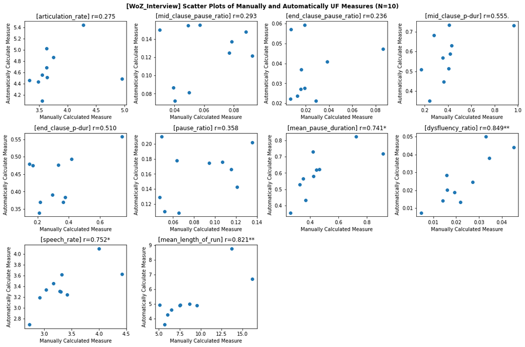

| UF measure | task | PF | r | p | sig |
| --- | --- | --- | --- | --- | --- |
| articulation_rate | WoZ_Interview | High | 0.274718 | 0.442391 |  |
| mid_clause_pause_ratio | WoZ_Interview | High | 0.292776 | 0.411684 |  |
| end_clause_pause_ratio | WoZ_Interview | High | 0.235832 | 0.511864 |  |
| mid_clause_p-dur | WoZ_Interview | High | 0.555400 | 0.095564 | . |
| end_clause_p-dur | WoZ_Interview | High | 0.509576 | 0.132445 |  |
| pause_ratio | WoZ_Interview | High | 0.358494 | 0.309045 |  |
| mean_pause_duration | WoZ_Interview | High | 0.741412 | 0.014122 | * |
| dysfluency_ratio | WoZ_Interview | High | 0.849097 | 0.001883 | ** |
| speech_rate | WoZ_Interview | High | 0.751891 | 0.012135 | * |
| mean_length_of_run | WoZ_Interview | High | 0.820923 | 0.003603 | ** |

```python
task = "WoZ_Interview"
rating_filter = [4, 5]
df_uf_manu, df_uf_auto = load_measures([task], rating_filter)
df_pearsonr = correlation_analysis(task, df_uf_manu, df_uf_auto, pf_group="High")
df_cor_list.append(df_pearsonr)
df_pearsonr
```

### 3.5 Summary

```python
df_cor_all = pd.concat(df_cor_list)
df_cor_all.to_csv("/home/matsuura/Development/app/feature_extraction_api/experiment/data/correlation_all_results.csv")
df_cor_all
```

| UF measure | task | PF | r | p | sig |
| --- | --- | --- | --- | --- | --- |
| articulation_rate | All Task | All | 0.589634 | 3.523876e-57 | *** |
| mid_clause_pause_ratio | All Task | All | 0.610434 | 3.098169e-62 | *** |
| end_clause_pause_ratio | All Task | All | 0.591114 | 1.582718e-57 | *** |
| mid_clause_p-dur | All Task | All | 0.831293 | 6.865514e-154 | *** |
| end_clause_p-dur | All Task | All | 0.722316 | 2.264776e-97 | *** |
| ... | ... | ... | ... | ... | ... |
| pause_ratio | WoZ_Interview | High | 0.358494 | 3.090453e-01 |  |
| mean_pause_duration | WoZ_Interview | High | 0.741412 | 1.412155e-02 | * |
| dysfluency_ratio | WoZ_Interview | High | 0.849097 | 1.883119e-03 | ** |
| speech_rate | WoZ_Interview | High | 0.751891 | 1.213480e-02 | * |
| mean_length_of_run | WoZ_Interview | High | 0.820923 | 3.602669e-03 | ** |

210 rows × 5 columns